# NC Homeless Data Project

### Import the necessary libraries

```python
import pandas as pd
import numpy as np
import seaborn as sns
import matplotlib.pyplot as plt
from sklearn.model_selection import train_test_split
from sklearn.ensemble import RandomForestRegressor
from sklearn.metrics import mean_squared_error, mean_absolute_error
import psycopg2
from dotenv import load_dotenv

import os
```

### Load the CSV files for each year into their own dataframe, then combine into a single dataframe

##### Data source:

##### HUD User. (2024). 2007 - 2024 Point-in-Time Estimates by State . huduser.gov. https://www.huduser.gov/portal/datasets/ahar/2024-ahar-part-1-pit-estimates-of-homelessness-in-the-us.html

```python
# Array to hold dataframes
df_array = []

# Load PIT Counts Data for each year from CSV files into a dataframe, then append the dataframe to the dataframes array
df = pd.read_csv('pit_counts_2007.csv')
df['Year'] = 2007;
df_array.append(df)

df = pd.read_csv('pit_counts_2008.csv')
df['Year'] = 2008;
df_array.append(df)

df = pd.read_csv('pit_counts_2009.csv')
df['Year'] = 2009;
df_array.append(df)

df = pd.read_csv('pit_counts_2010.csv')
df['Year'] = 2010;
df_array.append(df)

df = pd.read_csv('pit_counts_2011.csv')
df['Year'] = 2011;
df_array.append(df)

df = pd.read_csv('pit_counts_2012.csv')
df['Year'] = 2012;
df_array.append(df)

df = pd.read_csv('pit_counts_2013.csv')
df['Year'] = 2013;
df_array.append(df)

df = pd.read_csv('pit_counts_2014.csv')
df['Year'] = 2014;
df_array.append(df)

df = pd.read_csv('pit_counts_2015.csv')
df['Year'] = 2015;
df_array.append(df)

df = pd.read_csv('pit_counts_2016.csv')
df['Year'] = 2016;
df_array.append(df)

df = pd.read_csv('pit_counts_2017.csv')
df['Year'] = 2017;
df_array.append(df)

df = pd.read_csv('pit_counts_2018.csv')
df['Year'] = 2018;
df_array.append(df)

df = pd.read_csv('pit_counts_2019.csv')
df['Year'] = 2019;
df_array.append(df)

df = pd.read_csv('pit_counts_2020.csv')
df['Year'] = 2020;
df_array.append(df)

df = pd.read_csv('pit_counts_2021.csv')
df['Year'] = 2021;
df_array.append(df)

df = pd.read_csv('pit_counts_2022.csv')
df['Year'] = 2022;
df_array.append(df)

df = pd.read_csv('pit_counts_2023.csv')
df['Year'] = 2023;
df_array.append(df)

df = pd.read_csv('pit_counts_2024.csv')
df['Year'] = 2024;
df_array.append(df)

# Combine all dataframes in the dataframe array
pit_data = pd.concat(df_array, ignore_index=True)

# View the dataframe
pit_data.head()
```

|  | State | Number of CoCs | Overall Homeless | Sheltered ES Homeless | Sheltered TH Homeless | Sheltered Total Homeless | Unsheltered Homeless | Overall Homeless Individuals | Sheltered ES Homeless Individuals | Sheltered TH Homeless Individuals | ... | Unsheltered Homeless Parenting Youth (Under 25) - Black, African American, or African Only | Unsheltered Homeless Parenting Youth (Under 25) - Middle Eastern or North African and Hispanic/Latina/e/o | Unsheltered Homeless Parenting Youth (Under 25) - Middle Eastern or North African Only | Unsheltered Homeless Parenting Youth (Under 25) - Native Hawaiian or Other Pacific Islander and Hispanic/Latina/e/o | Unsheltered Homeless Parenting Youth (Under 25) - Native Hawaiian or Other Pacific Islander Only | Unsheltered Homeless Parenting Youth (Under 25) - White and Hispanic/Latina/e/o | Unsheltered Homeless Parenting Youth (Under 25) - White Only | Unsheltered Homeless Parenting Youth (Under 25) - Multi-Racial and Hispanic/Latina/e/o | Unsheltered Homeless Parenting Youth (Under 25) - Multi-Racial Only | Unsheltered Homeless Parenting Youth (Under 25) - Hispanic/Latina/e/o Only |
| --- | --- | --- | --- | --- | --- | --- | --- | --- | --- | --- | --- | --- | --- | --- | --- | --- | --- | --- | --- | --- | --- |
| 0 | AK | 2.0 | 1,642 | 898 | 489 | 1,387 | 255 | 1,062 | 618 | 273 | ... | NaN | NaN | NaN | NaN | NaN | NaN | NaN | NaN | NaN | NaN |
| 1 | AL | 8.0 | 5,452 | 1,452 | 2,344 | 3,796 | 1,656 | 4,184 | 1,210 | 1,613 | ... | NaN | NaN | NaN | NaN | NaN | NaN | NaN | NaN | NaN | NaN |
| 2 | AR | 9.0 | 3,836 | 1,251 | 1,034 | 2,285 | 1,551 | 2,987 | 985 | 781 | ... | NaN | NaN | NaN | NaN | NaN | NaN | NaN | NaN | NaN | NaN |
| 3 | AS | 0.0 |  |  |  |  |  |  |  |  | ... | NaN | NaN | NaN | NaN | NaN | NaN | NaN | NaN | NaN | NaN |
| 4 | AZ | 3.0 | 14,646 | 3,934 | 4,684 | 8,618 | 6,028 | 10,020 | 2,412 | 2,011 | ... | NaN | NaN | NaN | NaN | NaN | NaN | NaN | NaN | NaN | NaN |

5 rows × 1345 columns

### Remove all states except for NC

```python
# Filter for NC only
pit_data = pit_data[pit_data['State'] == 'NC']

# View the dataframe again
pit_data.head()
```

|  | State | Number of CoCs | Overall Homeless | Sheltered ES Homeless | Sheltered TH Homeless | Sheltered Total Homeless | Unsheltered Homeless | Overall Homeless Individuals | Sheltered ES Homeless Individuals | Sheltered TH Homeless Individuals | ... | Unsheltered Homeless Parenting Youth (Under 25) - Black, African American, or African Only | Unsheltered Homeless Parenting Youth (Under 25) - Middle Eastern or North African and Hispanic/Latina/e/o | Unsheltered Homeless Parenting Youth (Under 25) - Middle Eastern or North African Only | Unsheltered Homeless Parenting Youth (Under 25) - Native Hawaiian or Other Pacific Islander and Hispanic/Latina/e/o | Unsheltered Homeless Parenting Youth (Under 25) - Native Hawaiian or Other Pacific Islander Only | Unsheltered Homeless Parenting Youth (Under 25) - White and Hispanic/Latina/e/o | Unsheltered Homeless Parenting Youth (Under 25) - White Only | Unsheltered Homeless Parenting Youth (Under 25) - Multi-Racial and Hispanic/Latina/e/o | Unsheltered Homeless Parenting Youth (Under 25) - Multi-Racial Only | Unsheltered Homeless Parenting Youth (Under 25) - Hispanic/Latina/e/o Only |
| --- | --- | --- | --- | --- | --- | --- | --- | --- | --- | --- | --- | --- | --- | --- | --- | --- | --- | --- | --- | --- | --- |
| 30 | NC | 13.0 | 11,802 | 4,745 | 3,134 | 7,879 | 3,923 | 8,391 | 3,437 | 1,956 | ... | NaN | NaN | NaN | NaN | NaN | NaN | NaN | NaN | NaN | NaN |
| 88 | NC | 13.0 | 12,411 | 4,863 | 3,162 | 8,025 | 4,386 | 8,749 | 3,505 | 1,832 | ... | NaN | NaN | NaN | NaN | NaN | NaN | NaN | NaN | NaN | NaN |
| 146 | NC | 12.0 | 12,918 | 4,873 | 3,600 | 8,473 | 4,445 | 9,159 | 3,450 | 2,126 | ... | NaN | NaN | NaN | NaN | NaN | NaN | NaN | NaN | NaN | NaN |
| 204 | NC | 12.0 | 12,191 | 4,979 | 4,194 | 9,173 | 3,018 | 8,361 | 3,530 | 2,362 | ... | NaN | NaN | NaN | NaN | NaN | NaN | NaN | NaN | NaN | NaN |
| 262 | NC | 12.0 | 12,896 | 5,175 | 4,070 | 9,245 | 3,651 | 8,303 | 3,659 | 2,376 | ... | NaN | NaN | NaN | NaN | NaN | NaN | NaN | NaN | NaN | NaN |

5 rows × 1345 columns

### Keep only State, Year, Sheltered Total Homeless, Unsheltered Homeless, and Overall Homeless columns

```python
# Keep only specified columns
keep_columns = ['State', 'Year', 'Number of CoCs', 'Sheltered Total Homeless', 'Unsheltered Homeless', 'Overall Homeless']
pit_data = pit_data[keep_columns]

# View the dataframe again
pit_data.head()
```

|  | State | Year | Number of CoCs | Sheltered Total Homeless | Unsheltered Homeless | Overall Homeless |
| --- | --- | --- | --- | --- | --- | --- |
| 30 | NC | 2007 | 13.0 | 7,879 | 3,923 | 11,802 |
| 88 | NC | 2008 | 13.0 | 8,025 | 4,386 | 12,411 |
| 146 | NC | 2009 | 12.0 | 8,473 | 4,445 | 12,918 |
| 204 | NC | 2010 | 12.0 | 9,173 | 3,018 | 12,191 |
| 262 | NC | 2011 | 12.0 | 9,245 | 3,651 | 12,896 |

### Remove commas and convert to numeric values for homeless population columns

```python
# Clean PIT data: Remove commas, convert to numeric
def ToNumericRemoveCommas(x):
    x = x.str.replace(',', '')
    return pd.to_numeric(x)

pit_data['Sheltered Total Homeless'] = ToNumericRemoveCommas(pit_data['Sheltered Total Homeless'])
pit_data['Unsheltered Homeless'] = ToNumericRemoveCommas(pit_data['Unsheltered Homeless'])
pit_data['Overall Homeless'] = ToNumericRemoveCommas(pit_data['Overall Homeless'])

# View the dataframe again
pit_data.head()
```

|  | State | Year | Number of CoCs | Sheltered Total Homeless | Unsheltered Homeless | Overall Homeless |
| --- | --- | --- | --- | --- | --- | --- |
| 30 | NC | 2007 | 13.0 | 7879 | 3923 | 11802 |
| 88 | NC | 2008 | 13.0 | 8025 | 4386 | 12411 |
| 146 | NC | 2009 | 12.0 | 8473 | 4445 | 12918 |
| 204 | NC | 2010 | 12.0 | 9173 | 3018 | 12191 |
| 262 | NC | 2011 | 12.0 | 9245 | 3651 | 12896 |

### Check for Null Values

```python
# Check for nulls
print(pit_data.isna().sum())
```

```
State                       0
Year                        0
Number of CoCs              0
Sheltered Total Homeless    0
Unsheltered Homeless        0
Overall Homeless            0
dtype: int64
```

### Check for duplicates

```python
# Check for duplicates
duplicates = pit_data[pit_data.duplicated(subset=['Year'], keep=False)]
print("Number of duplicates:", len(duplicates))
```

```
Number of duplicates: 0
```

### Load NC population data from CSV

##### Data source:

##### St. Louis Fed. (2024). Resident Population in North Carolina (NCPOP). fred.stlouisfed.org. https://fred.stlouisfed.org/series/NCPOP

```python
# Load NC Population Data
pop_data = pd.read_csv('NCPOP.csv')
pop_data.head()
```

|  | observation_date | NCPOP |
| --- | --- | --- |
| 0 | 2007-01-01 | 9118.037 |
| 1 | 2008-01-01 | 9309.449 |
| 2 | 2009-01-01 | 9449.566 |
| 3 | 2010-01-01 | 9574.586 |
| 4 | 2011-01-01 | 9658.913 |

### Change column names, convert value types, and transform population values from 'thousands of people' to actual population

```python
pop_data['Year'] = pd.to_datetime(pop_data['observation_date']).dt.year.astype('int32').apply(int)
pop_data['Population'] = pop_data['NCPOP'] * 1000  # Convert thousands of persons to actual population
pop_data = pop_data[['Year', 'Population']]

pop_data.head()
```

|  | Year | Population |
| --- | --- | --- |
| 0 | 2007 | 9118037.0 |
| 1 | 2008 | 9309449.0 |
| 2 | 2009 | 9449566.0 |
| 3 | 2010 | 9574586.0 |
| 4 | 2011 | 9658913.0 |

### Merge the population data with the PIT data on the Year column

```python
merged = pd.merge(
    pit_data,
    pop_data,
    on='Year',
    how='left'
)

merged.head()
```

|  | State | Year | Number of CoCs | Sheltered Total Homeless | Unsheltered Homeless | Overall Homeless | Population |
| --- | --- | --- | --- | --- | --- | --- | --- |
| 0 | NC | 2007 | 13.0 | 7879 | 3923 | 11802 | 9118037.0 |
| 1 | NC | 2008 | 13.0 | 8025 | 4386 | 12411 | 9309449.0 |
| 2 | NC | 2009 | 12.0 | 8473 | 4445 | 12918 | 9449566.0 |
| 3 | NC | 2010 | 12.0 | 9173 | 3018 | 12191 | 9574586.0 |
| 4 | NC | 2011 | 12.0 | 9245 | 3651 | 12896 | 9658913.0 |

### Add a column for Homeless per 100k and calculate its values using overall homeless and population

```python
merged['Homeless Per 100k'] = (merged['Overall Homeless'] / merged['Population']) * 100000

print('Shape:', merged.shape)
merged.head()
```

```
Shape: (18, 8)
```

|  | State | Year | Number of CoCs | Sheltered Total Homeless | Unsheltered Homeless | Overall Homeless | Population | Homeless Per 100k |
| --- | --- | --- | --- | --- | --- | --- | --- | --- |
| 0 | NC | 2007 | 13.0 | 7879 | 3923 | 11802 | 9118037.0 | 129.435755 |
| 1 | NC | 2008 | 13.0 | 8025 | 4386 | 12411 | 9309449.0 | 133.316161 |
| 2 | NC | 2009 | 12.0 | 8473 | 4445 | 12918 | 9449566.0 | 136.704691 |
| 3 | NC | 2010 | 12.0 | 9173 | 3018 | 12191 | 9574586.0 | 127.326654 |
| 4 | NC | 2011 | 12.0 | 9245 | 3651 | 12896 | 9658913.0 | 133.513989 |

### Visualize the dataframe in a lineplot

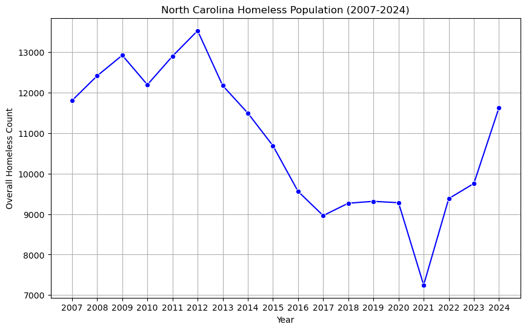

```python
# Visualize NC Homeless Trends
plt.figure(figsize=(10, 6))
sns.lineplot(data=merged, x='Year', y='Overall Homeless', marker='o', color='blue')
plt.title('North Carolina Homeless Population (2007-2024)')
plt.xlabel('Year')
plt.ylabel('Overall Homeless Count')
plt.grid(True)
plt.xticks(merged['Year'].astype(int))

plt.show()
```

### Notice the outlier for the year 2021. Describe the dataframe

```python
# Description of dataframe
merged.describe()
```

|  | Year | Number of CoCs | Sheltered Total Homeless | Unsheltered Homeless | Overall Homeless | Population | Homeless Per 100k |
| --- | --- | --- | --- | --- | --- | --- | --- |
| count | 18.000000 | 18.000000 | 18.000000 | 18.000000 | 18.000000 | 1.800000e+01 | 18.000000 |
| mean | 2015.500000 | 12.111111 | 7604.500000 | 3199.944444 | 10804.444444 | 1.009255e+07 | 107.984316 |
| std | 5.338539 | 0.323381 | 1187.498074 | 926.244185 | 1755.260303 | 5.527765e+05 | 21.998042 |
| min | 2007.000000 | 12.000000 | 5612.000000 | 1637.000000 | 7249.000000 | 9.118037e+06 | 68.617762 |
| 25% | 2011.250000 | 12.000000 | 6746.000000 | 2450.250000 | 9331.000000 | 9.682137e+06 | 88.902463 |
| 50% | 2015.500000 | 12.000000 | 7564.500000 | 3086.500000 | 11088.000000 | 1.009951e+07 | 105.852171 |
| 75% | 2019.750000 | 12.000000 | 8725.000000 | 3855.000000 | 12185.250000 | 1.048845e+07 | 128.908480 |
| max | 2024.000000 | 13.000000 | 9245.000000 | 4715.000000 | 13524.000000 | 1.104602e+07 | 138.681947 |

### Examine 2021 and surrounding years

```python
# Check 2021 Data
years_to_inspect = [2020, 2021, 2022]
df_years_to_inspect = merged[merged['Year'].isin(years_to_inspect)]

print(df_years_to_inspect[['Year', 'Overall Homeless', 'Sheltered Total Homeless', 'Unsheltered Homeless']])
```

```
    Year  Overall Homeless  Sheltered Total Homeless  Unsheltered Homeless
13  2020              9280                      6722                  2558
14  2021              7249                      5612                  1637
15  2022              9382                      5757                  3625
```

### Visualize the dataframe again, this time noting and annotating the outlier possibly due to Covid-19 affecting reporting

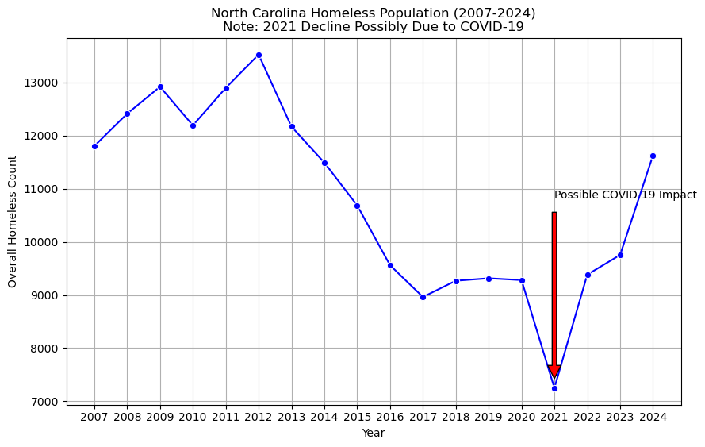

```python
# Visualize NC homeless Trends
plt.figure(figsize=(10, 6))
sns.lineplot(data=merged, x='Year', y='Overall Homeless', marker='o', color='blue')

plt.title('North Carolina Homeless Population (2007-2024)\nNote: 2021 Decline Possibly Due to COVID-19')
plt.xlabel('Year')
plt.ylabel('Overall Homeless Count')
plt.grid(True)
plt.xticks(merged['Year'].astype(int))

# Add annotation to possible Covid-19 impact
plt.annotate('Possible COVID-19 Impact', xy=(2021, merged[merged['Year'] == 2021]['Overall Homeless'].values[0]),
             xytext=(2021, merged['Overall Homeless'].max() * 0.8), arrowprops=dict(facecolor='red', shrink=0.05))

plt.show()
```

### Visualize sheltered bs unsheltered homeless population data

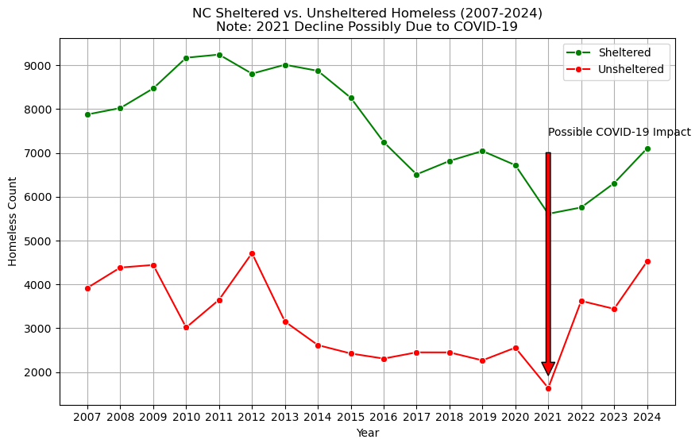

```python
# Visualize NC Sheltered vs. Unsheltered
plt.figure(figsize=(10, 6))
sns.lineplot(data=merged, x='Year', y='Sheltered Total Homeless', marker='o', label='Sheltered', color='green')
sns.lineplot(data=merged, x='Year', y='Unsheltered Homeless', marker='o', label='Unsheltered', color='red')

plt.title('NC Sheltered vs. Unsheltered Homeless (2007-2024)\nNote: 2021 Decline Possibly Due to COVID-19')
plt.xlabel('Year')
plt.ylabel('Homeless Count')
plt.grid(True)
plt.xticks(merged['Year'].astype(int))
plt.legend()

# Add annotation to possible Covid-19 impact
plt.annotate('Possible COVID-19 Impact', xy=(2021, merged[merged['Year'] == 2021]['Unsheltered Homeless'].values[0]),
             xytext=(2021, merged[['Sheltered Total Homeless', 'Unsheltered Homeless']].max().max() * 0.8),
             arrowprops=dict(facecolor='red', shrink=0.05))

plt.show()
```

### Plot NC homeless population vs NC total population

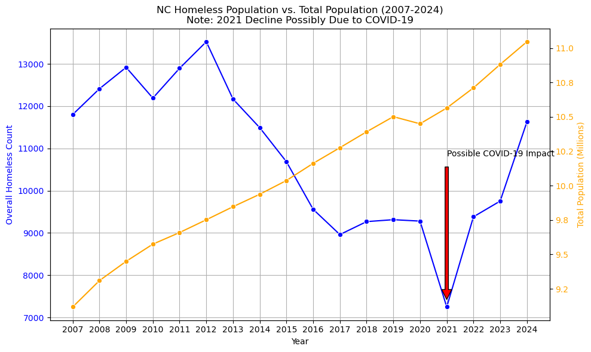

```python
# Visualize NC Homeless vs. Total Population
plt.figure(figsize=(10, 6))
fig, ax1 = plt.subplots(figsize=(10, 6))

# Plot Overall Homeless on left y-axis
ax1.set_xlabel('Year')
ax1.set_ylabel('Overall Homeless Count', color='blue')
line1 = sns.lineplot(data=merged, x='Year', y='Overall Homeless', marker='o', color='blue', ax=ax1)
ax1.tick_params(axis='y', labelcolor='blue')
ax1.grid(True)
ax1.set_xticks(merged['Year'].astype(int))

# Create second y-axis for Population
ax2 = ax1.twinx()
ax2.set_ylabel('Total Population (Millions)', color='orange')
line2 = sns.lineplot(data=merged, x='Year', y='Population', marker='o', color='orange', ax=ax2)
ax2.tick_params(axis='y', labelcolor='orange')

# Format right y-axis to show millions
ax2.yaxis.set_major_formatter(plt.FuncFormatter(lambda x, p: f'{x / 1e6:.1f}'))

# Add annotation to possible Covid-19 impact
ax1.annotate('Possible COVID-19 Impact', xy=(2021, merged[merged['Year'] == 2021]['Overall Homeless'].values[0]),
             xytext=(2021, merged['Overall Homeless'].max() * 0.8),
             arrowprops=dict(facecolor='red', shrink=0.05))

plt.title('NC Homeless Population vs. Total Population (2007-2024)\nNote: 2021 Decline Possibly Due to COVID-19')
fig.tight_layout()

plt.show()
```

### Create Random Forest model to predict 2025 homeless population

```python
state_data = merged[['Year', 'Overall Homeless']].dropna()

# Exclude 2021 to mitigate outlier impact
state_data = state_data[state_data['Year'] != 2021]

X = state_data[['Year']]
y = state_data['Overall Homeless']

# Split data into training and testing sets
X_train, X_test, y_train, y_test = train_test_split(X, y, test_size=0.2, random_state=42)

# Create Random Forest Regressor model
rf_model = RandomForestRegressor(n_estimators=10, max_depth=3, random_state=42)
rf_model.fit(X_train, y_train)
rf_preds = rf_model.predict(X_test)
rf_mse = mean_squared_error(y_test, rf_preds)
rf_rmse = np.sqrt(rf_mse)
rf_mae = mean_absolute_error(y_test, rf_preds)
rf_future = pd.DataFrame({'Year': [2025]})
rf_pred_2025 = rf_model.predict(rf_future)[0]

# Print findings
print("Mean Square Error:", rf_mse)
print("Root Mean Square Error:", rf_rmse)
print("Mean Absolute Error:", rf_mae)
print("2025 Prediction:", rf_pred_2025)
```

```
Mean Square Error: 425330.584338152
Root Mean Square Error: 652.1737378476322
Mean Absolute Error: 572.9684523809524
2025 Prediction: 10935.466666666665
```

### Visualize Random forest model prediction

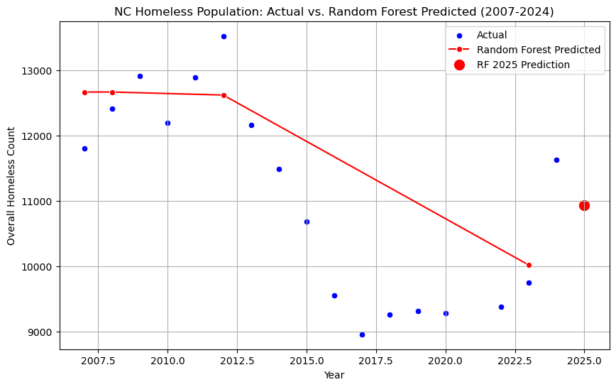

```python
# Visualize actual vs. predicted
plt.figure(figsize=(10, 6))
sns.scatterplot(x=state_data['Year'], y=state_data['Overall Homeless'], color='blue', label='Actual')
sns.lineplot(x=X_test['Year'], y=rf_preds, color='red', label='Random Forest Predicted', marker='o')
plt.scatter(x=[2025], y=[rf_pred_2025], color='red', s=100, label='RF 2025 Prediction')
plt.title('NC Homeless Population: Actual vs. Random Forest Predicted (2007-2024)')
plt.xlabel('Year')
plt.ylabel('Overall Homeless Count')
plt.grid(True)
plt.legend()

plt.show()
```

### Connect to SQL database (May take more than 1 attempt if database is sleeping)

```python
# Load environment variables from .env file
load_dotenv()

# Extract variables for database connection
USER = os.getenv("user")
PASSWORD = os.getenv("password")
HOST = os.getenv("host")
PORT = os.getenv("port")
DBNAME = os.getenv("dbname")

try:
    # Connect to PostgreSQL Database
    conn = psycopg2.connect(
        user=USER,
        password=PASSWORD,
        host=HOST,
        port=PORT,
        dbname=DBNAME
    )
    cursor = conn.cursor()
    print("Database Connection Successful!")

except Exception as e:
    print(f"Error connecting to database: {e}")
```

```
Database Connection Successful!
```

### Use SQL query to create table

```python
try:
    # SQL query - Create table
    create_table_query = """
    CREATE TABLE IF NOT EXISTS pit_counts (
        State VARCHAR(50),
        Year INTEGER,
        Number_of_CoCs INTEGER,
        Sheltered_Total_Homeless FLOAT,
        Unsheltered_Homeless FLOAT,
        Overall_Homeless FLOAT,
        Population FLOAT,
        Homeless_Per_100k FLOAT
    );
    """
    cursor.execute(create_table_query)
    conn.commit()
    print("Table 'pit_counts'succsesfully created!")

    # SQL query - Clear existing data (optional, to avoid duplicates)
    cursor.execute("TRUNCATE TABLE pit_counts;")
    conn.commit()

except Exception as e:
    print(f"Error uploading to Supabase: {e}")
```

```
Table 'pit_counts'succsesfully created!
```

### Prepare data to be inserted into database. Convert Numpy data types to standard Python data types

```python
# Prepare data for upload (handle NaN and numpy types)
upload_data = merged.copy()

# Convert to Python-native types
upload_data['State'] = upload_data['State'].astype(str).where(pd.notnull(upload_data['State']), None)
upload_data['Year'] = upload_data['Year'].apply(lambda x: int(x) if pd.notnull(x) else None)
upload_data['Number of CoCs'] = upload_data['Number of CoCs'].apply(lambda x: int(x) if pd.notnull(x) else None)
upload_data['Sheltered Total Homeless'] = upload_data['Sheltered Total Homeless'].apply(lambda x: float(x) if pd.notnull(x) else None)
upload_data['Unsheltered Homeless'] = upload_data['Unsheltered Homeless'].apply(lambda x: float(x) if pd.notnull(x) else None)
upload_data['Overall Homeless'] = upload_data['Overall Homeless'].apply(lambda x: float(x) if pd.notnull(x) else None)
upload_data['Population'] = upload_data['Population'].apply(lambda x: float(x) if pd.notnull(x) else None)
upload_data['Homeless Per 100k'] = upload_data['Homeless Per 100k'].apply(lambda x: float(x) if pd.notnull(x) else None)

print("Data types converted succsesfully!")
```

```
Data types converted succsesfully!
```

### Create array of rows to insert into database (fixes error involving naming issue of columns)

```python
# Create records using dictionary-style access to avoid naming issues
records = [
    (
        row['State'] if pd.notnull(row['State']) else None,
        row['Year'] if pd.notnull(row['Year']) else None,
        row['Number of CoCs'] if pd.notnull(row['Number of CoCs']) else None,
        row['Sheltered Total Homeless'] if pd.notnull(row['Sheltered Total Homeless']) else None,
        row['Unsheltered Homeless'] if pd.notnull(row['Unsheltered Homeless']) else None,
        row['Overall Homeless'] if pd.notnull(row['Overall Homeless']) else None,
        row['Population'] if pd.notnull(row['Population']) else None,
        row['Homeless Per 100k'] if pd.notnull(row['Homeless Per 100k']) else None
    )
    for _, row in upload_data.iterrows()
]

print("Records created succsesfully!")
```

```
Records created succsesfully!
```

### Use SQL query to insert rows from the records array into the table

```python
try:
     # SQL query
    insert_query = """
    INSERT INTO pit_counts (State, Year, Number_of_CoCs, Sheltered_Total_Homeless, Unsheltered_Homeless,
                           Overall_Homeless, Population, Homeless_Per_100k)
    VALUES (%s, %s, %s, %s, %s, %s, %s, %s);
    """
    cursor.executemany(insert_query, records)
    conn.commit()
    print("Uploaded rows succsesfully!")

except Exception as e:
    print(f"Error uploading to Supabase: {e}")
finally:
    if 'cursor' in locals():
        cursor.close()
    if 'conn' in locals():
        conn.close()
    print("Database connection closed")
```

```
Uploaded rows succsesfully!
Database connection closed
```